# Python for Data Science - Graded Project 2

## Problem Statement :

## Analyse & formulate clusters for E-commerce company using Unsupervised Learning

- Customer segmentation is one of the most important marketing tools at your disposal, because it can help a business to better understand its target audience. This is because it groups customers based on common characteristics.
- Segmentation can be based on the customer’s habits and lifestyle, in particular, their buying habits. Different age groups, for example, tend to spend their money in different ways, so brands need to be aware of who exactly is buying their product.
- Segmentation also focuses more on the personality of the consumer, including their opinions, interests, reviews, and rating. Breaking down a large customer base into more manageable clusters, making it easier to identify your target audience and launch campaigns and promote the business to the most relevant people.

## Dataset Description:

The dataset contains measurements of clothing fit from RentTheRunway. RentTheRunWay is a unique platform that allows women to rent clothes for various occasions. The collected data is of several categories. This dataset contains self-reported fit feedback from customers as well as other side information like reviews, ratings, product categories, catalog sizes, customers' measurements (etc.). The files provided are as follows:

- renttherunway-1.csv – data file.

## Attribute Information:

1. user_id - a unique id for the customer
2. item_id - unique product id
3. weight - weight measurement of customer
4. rented for - purpose clothing was rented for
5. body type - body type of customer
6. review_text - review given by the customer
7. size - the standardized size of the product
8. rating - rating for the product
9. age - age of the customer
10. category - the category of the product
11. bust size - bust measurement of customer
12. height - height of the customer
13. review_date - date when the review was written
14. fit - fit feedback

## 1. Import the required libraries and read the dataset.

```python
import numpy as np
import pandas as pd
%matplotlib inline
import matplotlib.pyplot as plt
import seaborn as sns
import warnings
warnings.filterwarnings('ignore')

import sklearn
from sklearn.model_selection import train_test_split
from sklearn.preprocessing import StandardScaler
from sklearn.preprocessing import LabelEncoder

from sklearn.decomposition import PCA
from sklearn import preprocessing
from sklearn.preprocessing import Normalizer
from sklearn.cluster import KMeans
from scipy.stats import zscore
from scipy.spatial import distance
from scipy.cluster.hierarchy import linkage, dendrogram, fcluster
from sklearn.cluster import AgglomerativeClustering
from sklearn.metrics import silhouette_score
```

```python
data = pd.read_csv(r'renttherunway.csv')
pd.set_option('display.max_columns', None)
data
```

|  | Unnamed: 0 | fit | user_id | bust size | item_id | weight | rating | rented for | review_text | body type | review_summary | category | height | size | age | review_date |
| --- | --- | --- | --- | --- | --- | --- | --- | --- | --- | --- | --- | --- | --- | --- | --- | --- |
| 0 | 0 | fit | 420272 | 34d | 2260466 | 137lbs | 10.0 | vacation | An adorable romper! Belt and zipper were a lit... | hourglass | So many compliments! | romper | 5' 8" | 14 | 28.0 | April 20, 2016 |
| 1 | 1 | fit | 273551 | 34b | 153475 | 132lbs | 10.0 | other | I rented this dress for a photo shoot. The the... | straight & narrow | I felt so glamourous!!! | gown | 5' 6" | 12 | 36.0 | June 18, 2013 |
| 2 | 2 | fit | 360448 | NaN | 1063761 | NaN | 10.0 | party | This hugged in all the right places! It was a ... | NaN | It was a great time to celebrate the (almost) ... | sheath | 5' 4" | 4 | 116.0 | December 14, 2015 |
| 3 | 3 | fit | 909926 | 34c | 126335 | 135lbs | 8.0 | formal affair | I rented this for my company's black tie award... | pear | Dress arrived on time and in perfect condition. | dress | 5' 5" | 8 | 34.0 | February 12, 2014 |
| 4 | 4 | fit | 151944 | 34b | 616682 | 145lbs | 10.0 | wedding | I have always been petite in my upper body and... | athletic | Was in love with this dress !!! | gown | 5' 9" | 12 | 27.0 | September 26, 2016 |
| ... | ... | ... | ... | ... | ... | ... | ... | ... | ... | ... | ... | ... | ... | ... | ... | ... |
| 192539 | 192539 | fit | 66386 | 34dd | 2252812 | 140lbs | 10.0 | work | Fit like a glove! | hourglass | LOVE IT!!! First Item Im thinking of buying! | jumpsuit | 5' 9" | 8 | 42.0 | May 18, 2016 |
| 192540 | 192540 | fit | 118398 | 32c | 682043 | 100lbs | 10.0 | work | The pattern contrast on this dress is really s... | petite | LOVE it! | dress | 5' 1" | 4 | 29.0 | September 30, 2016 |
| 192541 | 192541 | fit | 47002 | 36a | 683251 | 135lbs | 6.0 | everyday | Like the other DVF wraps, the fit on this is f... | straight & narrow | Loud patterning, flattering fit | dress | 5' 8" | 8 | 31.0 | March 4, 2016 |
| 192542 | 192542 | fit | 961120 | 36c | 126335 | 165lbs | 10.0 | wedding | This dress was PERFECTION. it looked incredib... | pear | loved this dress it was comfortable and photog... | dress | 5' 6" | 16 | 31.0 | November 25, 2015 |
| 192543 | 192543 | fit | 123612 | 36b | 127865 | 155lbs | 10.0 | wedding | This dress was wonderful! I had originally pla... | athletic | I wore this to a beautiful black tie optional ... | gown | 5' 6" | 16 | 30.0 | August 29, 2017 |

192544 rows × 16 columns

## 2. Check the first few samples, shape, info of the data and try to familiarize yourself with different features.

```python
data.head()
```

|  | Unnamed: 0 | fit | user_id | bust size | item_id | weight | rating | rented for | review_text | body type | review_summary | category | height | size | age | review_date |
| --- | --- | --- | --- | --- | --- | --- | --- | --- | --- | --- | --- | --- | --- | --- | --- | --- |
| 0 | 0 | fit | 420272 | 34d | 2260466 | 137lbs | 10.0 | vacation | An adorable romper! Belt and zipper were a lit... | hourglass | So many compliments! | romper | 5' 8" | 14 | 28.0 | April 20, 2016 |
| 1 | 1 | fit | 273551 | 34b | 153475 | 132lbs | 10.0 | other | I rented this dress for a photo shoot. The the... | straight & narrow | I felt so glamourous!!! | gown | 5' 6" | 12 | 36.0 | June 18, 2013 |
| 2 | 2 | fit | 360448 | NaN | 1063761 | NaN | 10.0 | party | This hugged in all the right places! It was a ... | NaN | It was a great time to celebrate the (almost) ... | sheath | 5' 4" | 4 | 116.0 | December 14, 2015 |
| 3 | 3 | fit | 909926 | 34c | 126335 | 135lbs | 8.0 | formal affair | I rented this for my company's black tie award... | pear | Dress arrived on time and in perfect condition. | dress | 5' 5" | 8 | 34.0 | February 12, 2014 |
| 4 | 4 | fit | 151944 | 34b | 616682 | 145lbs | 10.0 | wedding | I have always been petite in my upper body and... | athletic | Was in love with this dress !!! | gown | 5' 9" | 12 | 27.0 | September 26, 2016 |

```python
data.info()
```

```
<class 'pandas.core.frame.DataFrame'>
RangeIndex: 192544 entries, 0 to 192543
Data columns (total 16 columns):
 #   Column          Non-Null Count   Dtype
---  ------          --------------   -----
 0   Unnamed: 0      192544 non-null  int64
 1   fit             192544 non-null  object
 2   user_id         192544 non-null  int64
 3   bust size       174133 non-null  object
 4   item_id         192544 non-null  int64
 5   weight          162562 non-null  object
 6   rating          192462 non-null  float64
 7   rented for      192534 non-null  object
 8   review_text     192482 non-null  object
 9   body type       177907 non-null  object
 10  review_summary  192199 non-null  object
 11  category        192544 non-null  object
 12  height          191867 non-null  object
 13  size            192544 non-null  int64
 14  age             191584 non-null  float64
 15  review_date     192544 non-null  object
dtypes: float64(2), int64(4), object(10)
memory usage: 23.5+ MB
```

```python
data.shape
```

```
(192544, 16)
```

```python
data.size
```

```
3080704
```

```python
data.ndim
```

```
2
```

```python
data["fit"].ndim
```

```
1
```

```python
data.describe()
```

|  | Unnamed: 0 | user_id | item_id | rating | size | age |
| --- | --- | --- | --- | --- | --- | --- |
| count | 192544.000000 | 192544.000000 | 1.925440e+05 | 192462.000000 | 192544.000000 | 191584.000000 |
| mean | 96271.500000 | 499494.100149 | 1.045684e+06 | 9.092371 | 12.245175 | 33.871017 |
| std | 55582.809453 | 289059.719328 | 8.053148e+05 | 1.430044 | 8.494877 | 8.058083 |
| min | 0.000000 | 9.000000 | 1.233730e+05 | 2.000000 | 0.000000 | 0.000000 |
| 25% | 48135.750000 | 250654.250000 | 1.950760e+05 | 8.000000 | 8.000000 | 29.000000 |
| 50% | 96271.500000 | 499419.000000 | 9.483960e+05 | 10.000000 | 12.000000 | 32.000000 |
| 75% | 144407.250000 | 750974.000000 | 1.678888e+06 | 10.000000 | 16.000000 | 37.000000 |
| max | 192543.000000 | 999997.000000 | 2.966087e+06 | 10.000000 | 58.000000 | 117.000000 |

- Average age of customer in the given dataset is '33'.
- Average rating of the products is 9.09 with minimun of 2 and a maximun of 10

```python
data.describe(include = 'O')
```

|  | fit | bust size | weight | rented for | review_text | body type | review_summary | category | height | review_date |
| --- | --- | --- | --- | --- | --- | --- | --- | --- | --- | --- |
| count | 192544 | 174133 | 162562 | 192534 | 192482 | 177907 | 192199 | 192544 | 191867 | 192544 |
| unique | 3 | 106 | 190 | 9 | 191027 | 7 | 154736 | 68 | 24 | 2274 |
| top | fit | 34b | 130lbs | wedding | . | hourglass | Stylist Review | dress | 5' 4" | June 15, 2016 |
| freq | 142058 | 27285 | 14370 | 57784 | 63 | 55349 | 977 | 92884 | 28012 | 844 |

- There are 192544 entries and 16 columns in the dataset
- It consists of integer, float and object type of data
- Entire size of data is: (192544 x 16) = 3080704
- The dataframe is 2 dimentional (columns and rows); The entries of the column are 1 dimentional data
- It is evident that there are some null entries also in some columns

## Data cleansing and Exploratory data analysis

## 3. Check if there are any duplicate records in the dataset? If any, drop them.

```python
data[data.duplicated()].sum()
```

```
Unnamed: 0        0.0
fit               0.0
user_id           0.0
bust size         0.0
item_id           0.0
weight            0.0
rating            0.0
rented for        0.0
review_text       0.0
body type         0.0
review_summary    0.0
category          0.0
height            0.0
size              0.0
age               0.0
review_date       0.0
dtype: float64
```

```python
data[data.duplicated()].shape
```

```
(0, 16)
```

- There are no duplicate records in the dataset.

## 4. Drop the columns which you think redundant for the analysis.

```python
data = data.drop(columns=data.columns[0])
data = data.drop(['user_id','item_id','review_text','review_summary','review_date'], axis = 1)

data.head()
```

|  | fit | bust size | weight | rating | rented for | body type | category | height | size | age |
| --- | --- | --- | --- | --- | --- | --- | --- | --- | --- | --- |
| 0 | fit | 34d | 137lbs | 10.0 | vacation | hourglass | romper | 5' 8" | 14 | 28.0 |
| 1 | fit | 34b | 132lbs | 10.0 | other | straight & narrow | gown | 5' 6" | 12 | 36.0 |
| 2 | fit | NaN | NaN | 10.0 | party | NaN | sheath | 5' 4" | 4 | 116.0 |
| 3 | fit | 34c | 135lbs | 8.0 | formal affair | pear | dress | 5' 5" | 8 | 34.0 |
| 4 | fit | 34b | 145lbs | 10.0 | wedding | athletic | gown | 5' 9" | 12 | 27.0 |

## 5. Check the column 'weight', Is there any presence of string data? If yes, remove the string data and convert to float.

```python
print('Total entries with null values in column "weight": ', data.weight.isnull().sum())

data[["weight"]] = data[["weight"]].fillna('0lbs')
```

```
Total entries with null values in column "weight":  29982
```

```python
data.weight = [float(x.strip('lbs')) for x in data.weight]
data.weight
```

```
0         137.0
1         132.0
2           0.0
3         135.0
4         145.0
          ...
192539    140.0
192540    100.0
192541    135.0
192542    165.0
192543    155.0
Name: weight, Length: 192544, dtype: float64
```

- Due to the presence of some null values, we cannot perform required weight data handling directly. Hence performing imputation for the missing entries initially
- Removed the 'lbs' from weight entries and converted it to float as per the requirement

## 6. Check the unique categories for the column 'rented for' and group 'party:cocktail' category with 'party'.

```python
data['rented for'].unique()
```

```
array(['vacation', 'other', 'party', 'formal affair', 'wedding', 'date',
       'everyday', 'work', nan, 'party: cocktail'], dtype=object)
```

```python
data['rented for'] = data['rented for'].replace('party: cocktail','party')

data['rented for'].unique()
```

```
array(['vacation', 'other', 'party', 'formal affair', 'wedding', 'date',
       'everyday', 'work', nan], dtype=object)
```

```python
data['rented for'].value_counts()
```

```
wedding          57784
formal affair    40408
party            35627
everyday         16822
other            15388
work             15042
date              7388
vacation          4075
Name: rented for, dtype: int64
```

- Checked the unique attributes of "rented for" column and changed a selected category ('party: cocktail') to 'party'

## 7. The column 'height' is in feet with a quotation mark, Convert to inches with float datatype.

```python
data.height = ['0' if 'nan' in x else ((float(str(x).split("'")[0]) * 12) + (float(str(x).split("'")[1].strip('"'))) )
                                          for x in data.height.astype(str)]
data.height = data.height.astype(float)

data.sample(8)
```

|  | fit | bust size | weight | rating | rented for | body type | category | height | size | age |
| --- | --- | --- | --- | --- | --- | --- | --- | --- | --- | --- |
| 93233 | fit | 34c | 110.0 | 10.0 | date | petite | dress | 61.0 | 4 | 32.0 |
| 23526 | large | 34b | 130.0 | 10.0 | wedding | athletic | maxi | 64.0 | 4 | 32.0 |
| 12860 | small | 32c | 120.0 | 8.0 | wedding | hourglass | shift | 63.0 | 4 | 23.0 |
| 117283 | fit | 34c | 115.0 | 10.0 | formal affair | petite | dress | 62.0 | 1 | 37.0 |
| 64202 | fit | 32a | 110.0 | 10.0 | other | pear | dress | 65.0 | 4 | 26.0 |
| 21945 | fit | 32c | 113.0 | 8.0 | party | hourglass | dress | 66.0 | 4 | 54.0 |
| 32952 | fit | 32c | 0.0 | 10.0 | formal affair | athletic | dress | 67.0 | 14 | 28.0 |
| 81191 | fit | 32c | 105.0 | 10.0 | other | petite | dress | 62.0 | 4 | 25.0 |

- "Height" column is converted to Float datatype (dtype: float64)
- Quotation mark has been removed and now height is in inches

## 8. Check for missing values in each column of the dataset? If it exists, impute them with appropriate methods.

```python
data.isnull().sum()
```

```
fit               0
bust size     18411
weight            0
rating           82
rented for       10
body type     14637
category          0
height            0
size              0
age             960
dtype: int64
```

```python
categorical_columns = data.select_dtypes('object')
numerical_columns = data.select_dtypes('float64')

for i in categorical_columns:
    data[i] = data[[i]].fillna('Missing')

for i in numerical_columns:
    data[i] = data[[i]].fillna(0)
```

```python
data.isnull().sum()
```

```
fit           0
bust size     0
weight        0
rating        0
rented for    0
body type     0
category      0
height        0
size          0
age           0
dtype: int64
```

- Total count of missing entries in each column is observed
- All null or NaN values are imputed as:
  - 0 for float datatype
  - 'Missing' for object datatype (string)
- Finally, all column information is retrieved and it is verified that there are no null values in the dataset

## 9. Check the statistical summary for the numerical and categorical columns and write your findings

```python
data.describe()
```

|  | weight | rating | height | size | age |
| --- | --- | --- | --- | --- | --- |
| count | 192544.000000 | 192544.000000 | 192544.000000 | 192544.000000 | 192544.000000 |
| mean | 115.997751 | 9.088499 | 65.080984 | 12.245175 | 33.702141 |
| std | 53.726993 | 1.441995 | 4.691938 | 8.494877 | 8.384539 |
| min | 0.000000 | 0.000000 | 0.000000 | 0.000000 | 0.000000 |
| 25% | 115.000000 | 8.000000 | 63.000000 | 8.000000 | 29.000000 |
| 50% | 130.000000 | 10.000000 | 65.000000 | 12.000000 | 32.000000 |
| 75% | 145.000000 | 10.000000 | 67.000000 | 16.000000 | 37.000000 |
| max | 300.000000 | 10.000000 | 78.000000 | 58.000000 | 117.000000 |

```python
data.describe(include = 'O')
```

|  | fit | bust size | rented for | body type | category |
| --- | --- | --- | --- | --- | --- |
| count | 192544 | 192544 | 192544 | 192544 | 192544 |
| unique | 3 | 107 | 9 | 8 | 68 |
| top | fit | 34b | wedding | hourglass | dress |
| freq | 142058 | 27285 | 57784 | 55349 | 92884 |

## 10. Are there outliers present in the column age? If yes, treat them with the appropriate method.

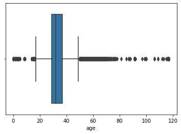

```python
sns.boxplot(data['age'])
```

```python
Q1 = data['age'].quantile(0.25)
Q2 = data['age'].quantile(0.5)
Q3 = data['age'].quantile(0.75)

IQR = Q3 - Q1

lower_limit = Q1 - 1.5*IQR
upper_limit = Q3 + 1.5*IQR

data['age'].where(data['age'] <= upper_limit, upper_limit, inplace=True)
data['age'].where(data['age'] >= lower_limit, lower_limit, inplace=True)
outliers = (data['age'] < lower_limit) | (data['age'] > upper_limit)
```

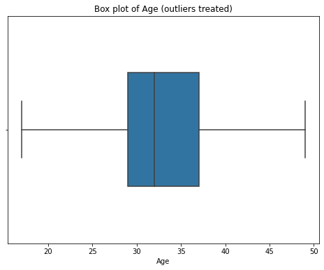

```python
plt.figure(figsize=(8,6))
sns.boxplot(x=data['age'], width=0.5)
plt.title('Box plot of Age (outliers treated)')
plt.xlabel('Age')
plt.show()
```

```python
print("Value of Q1 : ",Q1)
print("Value of Q2 : ",Q2)
print("Value of Q3 : ",Q3)
print("Value of IQR : ",IQR)
print("Value of Lower_limit : ",lower_limit)
print("Value of upper_limit : ",upper_limit)
```

```
Value of Q1 :  29.0
Value of Q2 :  32.0
Value of Q3 :  37.0
Value of IQR :  8.0
Value of Lower_limit :  17.0
Value of upper_limit :  49.0
```

## 11. Check the distribution of the different categories in the column 'rented for' using appropriate plot.

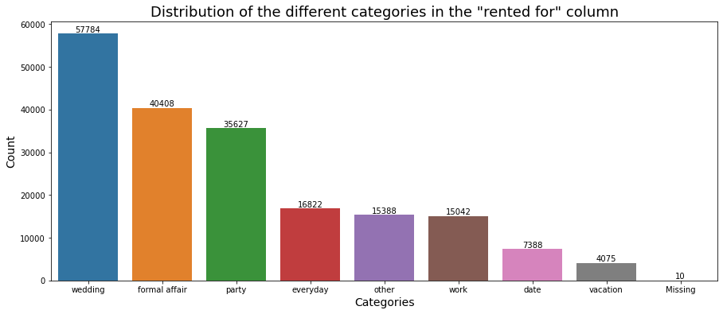

```python
plt.figure(figsize = (15, 6))
rented_df = sns.countplot(x='rented for', data=data,  order=data['rented for'].value_counts().index)

rented_df.set_xlabel(xlabel = 'Categories', fontsize = 14)
rented_df.set_ylabel(ylabel = 'Count', fontsize = 14)
rented_df.set_title(label = 'Distribution of the different categories in the "rented for" column', fontsize = 18)

rented_df.bar_label(rented_df.containers[0], fontsize = 10)

plt.show()
```

- The above plots show the distribution of Rented-for categories over the dataset
- It is observed that customers rent outfits mostly for 'weddings' followed by 'formal affair' and least for 'vacation'
- The number of customers who rented their costumes for weddings range about 57784 (approx 58,000) which computes to 30% of total categories
- The least used purpose like 'vacation' includes about 4075 entries (2%) and 'date' includes 7388 entries (4%)

## Data Preparation for model building

## 12. Encode the categorical variables in the dataset.

```python
labenc = LabelEncoder()
for i in categorical_columns:
    data[i] = data[[i]].apply(labenc.fit_transform)

data.head()
```

|  | fit | bust size | weight | rating | rented for | body type | category | height | size | age |
| --- | --- | --- | --- | --- | --- | --- | --- | --- | --- | --- |
| 0 | 0 | 39 | 137.0 | 10.0 | 6 | 4 | 44 | 68.0 | 14 | 28.0 |
| 1 | 0 | 37 | 132.0 | 10.0 | 4 | 7 | 20 | 66.0 | 12 | 36.0 |
| 2 | 0 | 106 | 0.0 | 10.0 | 5 | 0 | 45 | 64.0 | 4 | 49.0 |
| 3 | 0 | 38 | 135.0 | 8.0 | 3 | 5 | 16 | 65.0 | 8 | 34.0 |
| 4 | 0 | 37 | 145.0 | 10.0 | 7 | 2 | 20 | 69.0 | 12 | 27.0 |

- All categorical columns are encoded and now converted to numerical type using the LabelEncoder technique

## 13. Standardize the data, so that the values are within a particular range.

```python
data1 = data.copy()
scaled_features = StandardScaler().fit_transform(data1.values)
scaled_features_df = pd.DataFrame(scaled_features, index = data1.index, columns = data1.columns)

scaled_features_df.head()
```

|  | fit | bust size | weight | rating | rented for | body type | category | height | size | age |
| --- | --- | --- | --- | --- | --- | --- | --- | --- | --- | --- |
| 0 | -0.556291 | -0.295959 | 0.390908 | 0.632113 | 0.514533 | 0.178145 | 1.569310 | 0.622136 | 0.206575 | -0.770682 |
| 1 | -0.556291 | -0.384988 | 0.297845 | 0.632113 | -0.456520 | 1.763791 | -0.307247 | 0.195872 | -0.028862 | 0.364072 |
| 2 | -0.556291 | 2.686512 | -2.159027 | 0.632113 | 0.029006 | -1.936050 | 1.647500 | -0.230392 | -0.970608 | 2.208046 |
| 3 | -0.556291 | -0.340473 | 0.353683 | -0.754859 | -0.942047 | 0.706694 | -0.620006 | -0.017260 | -0.499735 | 0.080383 |
| 4 | -0.556291 | -0.384988 | 0.539809 | 0.632113 | 1.000060 | -0.878953 | -0.307247 | 0.835268 | -0.028862 | -0.912526 |

- The provided dataset is standardized using the Standard Scaler technique and all columns are brought to a particular range for performing computation and analysis

## Principal Component Analysis and Clustering

## 14. Apply PCA on the above dataset and determine the number of PCA components to be used so that 90-95% of the variance in data is explained by the same.

```python
cov_matrix = np.cov(scaled_features.T)
cov_matrix
```

```
array([[ 1.00000519e+00,  2.50158302e-03,  1.08364122e-02,
        -2.42452840e-01,  8.42615981e-03, -6.72087822e-03,
         3.35892077e-04, -1.31716413e-03,  6.54006939e-02,
         6.32684095e-04],
       [ 2.50158302e-03,  1.00000519e+00, -1.29927221e-01,
        -2.82402302e-03,  3.80109361e-03, -2.38681523e-01,
        -8.12084214e-03,  3.53832782e-02,  3.69772205e-01,
         7.54633396e-02],
       [ 1.08364122e-02, -1.29927221e-01,  1.00000519e+00,
        -9.24412628e-03, -8.87810298e-04,  5.20226207e-02,
         3.00232412e-03,  8.02723021e-02,  8.77275791e-02,
         7.79853450e-02],
       [-2.42452840e-01, -2.82402302e-03, -9.24412628e-03,
         1.00000519e+00,  1.37572723e-02, -1.02927478e-02,
        -2.23637380e-02,  4.14759256e-03, -3.63556284e-02,
        -4.16330609e-02],
       [ 8.42615981e-03,  3.80109361e-03, -8.87810298e-04,
         1.37572723e-02,  1.00000519e+00, -1.92965568e-02,
        -5.76358771e-02, -1.31762419e-02,  4.98053503e-03,
        -3.67695984e-02],
       [-6.72087822e-03, -2.38681523e-01,  5.20226207e-02,
        -1.02927478e-02, -1.92965568e-02,  1.00000519e+00,
         2.76586265e-04, -5.12440146e-02, -1.83605586e-01,
        -3.39756319e-03],
       [ 3.35892077e-04, -8.12084214e-03,  3.00232412e-03,
        -2.23637380e-02, -5.76358771e-02,  2.76586265e-04,
         1.00000519e+00, -4.27168945e-03, -5.62602705e-03,
         2.58261233e-02],
       [-1.31716413e-03,  3.53832782e-02,  8.02723021e-02,
         4.14759256e-03, -1.31762419e-02, -5.12440146e-02,
        -4.27168945e-03,  1.00000519e+00,  1.25981229e-01,
         8.36945301e-03],
       [ 6.54006939e-02,  3.69772205e-01,  8.77275791e-02,
        -3.63556284e-02,  4.98053503e-03, -1.83605586e-01,
        -5.62602705e-03,  1.25981229e-01,  1.00000519e+00,
         1.54750468e-01],
       [ 6.32684095e-04,  7.54633396e-02,  7.79853450e-02,
        -4.16330609e-02, -3.67695984e-02, -3.39756319e-03,
         2.58261233e-02,  8.36945301e-03,  1.54750468e-01,
         1.00000519e+00]])
```

```python
eig_values, eig_vectors = np.linalg.eig(cov_matrix)
print('Eigen values: ', '\n', eig_values)
print('\n')
print('Eigen vectors: ','\n',eig_vectors)
```

```
Eigen values:
 [1.60563724 0.56492754 1.25815961 1.16143744 0.75010184 0.79730815
 1.06779673 0.85857426 0.99100542 0.9451037 ]


Eigen vectors:
 [[-0.10736654 -0.09919695  0.61988755  0.30444401  0.67216527  0.13486895
  -0.11863549  0.08888289 -0.09679401 -0.01860787]
 [-0.58210631 -0.6675556  -0.18807217  0.19118049 -0.13767654  0.32683689
   0.09056127 -0.05355107  0.07307641 -0.03760635]
 [ 0.01518113 -0.29437664  0.266316   -0.64353002 -0.1227457   0.07705542
  -0.2509406   0.56923535  0.02476138  0.13942593]
 [ 0.0889494  -0.01733977 -0.64558544 -0.26088602  0.67320267  0.2054025
  -0.01218177  0.09885688  0.02477705  0.03191006]
 [-0.00345996 -0.01142572 -0.0817076   0.16895383 -0.02280242 -0.028508
  -0.62859175 -0.23014433  0.25578398  0.67065927]
 [ 0.43082225 -0.06459163  0.20126156 -0.19315098 -0.08817199  0.69023581
   0.024916   -0.4419668   0.20299605 -0.10509028]
 [ 0.00199688 -0.00094476  0.10053469 -0.08994552  0.02866479  0.08526515
   0.62633685 -0.04172488 -0.26559929  0.71352931]
 [-0.19596349 -0.09033208  0.03444215 -0.38300379  0.05273523 -0.14410393
  -0.26190927 -0.5264831  -0.65531669 -0.08241623]
 [-0.60170783  0.66361962  0.04627977 -0.16158772 -0.05440931  0.39341216
  -0.05722387  0.05925969  0.06844064  0.01001889]
 [-0.23538149 -0.068679    0.17901355 -0.37659804  0.21474026 -0.40842734
   0.2338534  -0.35311805  0.61054387 -0.03060967]]
```

```python
total = sum(eig_values)
var_exp = [(i/total)*100 for i in sorted(eig_values, reverse=True)]
cum_var_exp = np.cumsum(var_exp)

print('Explained Variance: ','\n', var_exp)
print('\n')
print('Cummulative Variance Explained: ','\n', cum_var_exp)
```

```
Explained Variance:
 [16.056289016790394, 12.581530786903675, 11.614314042294273, 10.677911810091459, 9.910002725651001, 9.450987956502498, 8.585698040518675, 7.973040120050108, 7.500979475968775, 5.649246025229127]


Cummulative Variance Explained:
 [ 16.05628902  28.6378198   40.25213385  50.93004566  60.84004838
  70.29103634  78.87673438  86.8497745   94.35075397 100.        ]
```

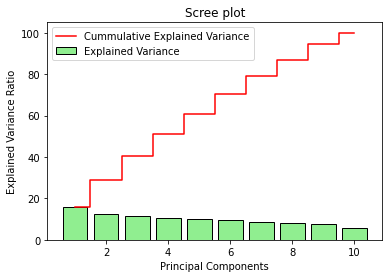

```python
plt.bar(range(1,len(var_exp)+1), var_exp, align='center', color='lightgreen', edgecolor='black', label='Explained Variance')
plt.step(range(1,len(var_exp)+1), cum_var_exp, where='mid', color='red', label='Cummulative Explained Variance')
plt.xlabel('Principal Components')
plt.ylabel('Explained Variance Ratio')
plt.title('Scree plot')
plt.legend(loc='best')
plt.show()
```

## 15. Apply K-means clustering and segment the data. (You may use original data or PCA transformed data).

```python
pca = PCA(n_components = 8)

pca_df = pd.DataFrame(pca.fit_transform(scaled_features_df), columns=['PC1','PC2','PC3','PC4','PC5','PC6','PC7','PC8'])
pca_df.head()
```

|  | PC1 | PC2 | PC3 | PC4 | PC5 | PC6 | PC7 | PC8 |
| --- | --- | --- | --- | --- | --- | --- | --- | --- |
| 0 | -0.307459 | -0.548546 | -0.712463 | 0.242332 | -1.055569 | 1.516645 | -0.054380 | 0.536688 |
| 1 | -0.998712 | -0.169214 | -1.197181 | 0.122651 | 0.463574 | -0.651805 | -0.691841 | 0.967905 |
| 2 | 2.202125 | -1.717138 | 1.212938 | 2.441038 | 0.821861 | 0.968597 | -1.295485 | -1.680661 |
| 3 | -0.787780 | 0.448251 | -0.447929 | 0.228958 | 0.112375 | -1.106116 | -0.023077 | -0.079271 |
| 4 | -0.033981 | -0.962178 | -0.360476 | -1.385509 | -0.892757 | 0.622906 | 0.392833 | -0.449833 |

### a) Find the optimal K Value using elbow plot for K Means clustering.

```python
cluster_errors = []
cluster_range = range(1,14)

for num_cluster in cluster_range:
    clusters = KMeans(num_cluster, random_state=100)
    clusters.fit(pca_df)
    cluster_errors.append(clusters.inertia_)
```

```python
cluster_df = pd.DataFrame({'num_cluster': cluster_range, 'cluster_errors': cluster_errors})
```

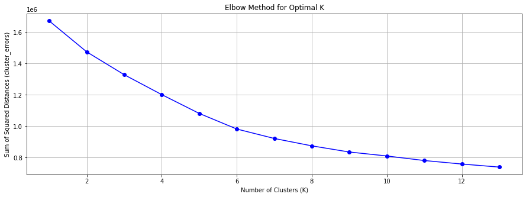

```python
plt.figure(figsize=[15,5])
plt.plot(cluster_range, cluster_errors, marker='o', color='b', linestyle='-')
plt.xlabel('Number of Clusters (K)')
plt.ylabel('Sum of Squared Distances (cluster_errors)')
plt.title('Elbow Method for Optimal K')
plt.grid(True)
plt.show()
```

### b) Build a Kmeans clustering model using the obtained optimal K .

```python
optimal_k = 2

kmeans = KMeans(n_clusters = optimal_k, random_state=100)
kmeans.fit(pca_df)
```

```
KMeans(n_clusters=2, random_state=100)
```

```python
label = pd.DataFrame(kmeans.labels_, columns=['Label'])

kmeans_df = pca_df.join(label)
kmeans_df.head()
```

|  | PC1 | PC2 | PC3 | PC4 | PC5 | PC6 | PC7 | PC8 | Label |
| --- | --- | --- | --- | --- | --- | --- | --- | --- | --- |
| 0 | -0.307459 | -0.548546 | -0.712463 | 0.242332 | -1.055569 | 1.516645 | -0.054380 | 0.536688 | 0 |
| 1 | -0.998712 | -0.169214 | -1.197181 | 0.122651 | 0.463574 | -0.651805 | -0.691841 | 0.967905 | 0 |
| 2 | 2.202125 | -1.717138 | 1.212938 | 2.441038 | 0.821861 | 0.968597 | -1.295485 | -1.680661 | 1 |
| 3 | -0.787780 | 0.448251 | -0.447929 | 0.228958 | 0.112375 | -1.106116 | -0.023077 | -0.079271 | 0 |
| 4 | -0.033981 | -0.962178 | -0.360476 | -1.385509 | -0.892757 | 0.622906 | 0.392833 | -0.449833 | 0 |

```python
kmeans_df['Label'].value_counts()
```

```
0    152790
1     39754
Name: Label, dtype: int64
```

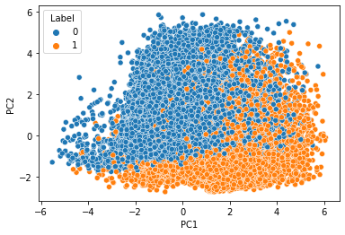

```python
sns.scatterplot(kmeans_df['PC1'], kmeans_df['PC2'], hue='Label', data=kmeans_df)
plt.show()
```

### c) Compute silhouette score for evaluating the quality of the K Means clustering technique

```python
from sklearn.metrics import silhouette_score

kmeans_score = []

for i in range(2,6):
    kmeans = KMeans(n_clusters = i)
    kmeans = kmeans.fit(pca_df)
    labels = kmeans.predict(pca_df)
    print("Silhouette_score : ",'\n',i, silhouette_score(pca_df, labels))
```

```
Silhouette_score :
 2 0.20839047193460794
Silhouette_score :
 3 0.14082158828287256
Silhouette_score :
 4 0.1747075860418141
Silhouette_score :
 5 0.1799933620075528
```

## 16. Apply Agglomerative clustering and segment the data. (You may use original data or PCA transformed data)

```python
scaled_features_sample = scaled_features[:1000,:]
print('Shape of scaled_features of the complete dataset: ', scaled_features.shape)
print('Shape of scaled_features of the sample dataset: ', scaled_features_sample.shape)
```

```
Shape of scaled_features of the complete dataset:  (192544, 10)
Shape of scaled_features of the sample dataset:  (1000, 10)
```

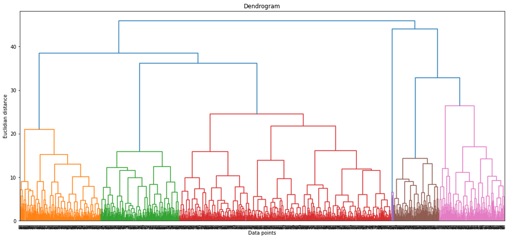

```python
plt.figure(figsize=[18,12])
merg = linkage(scaled_features_sample, method='ward')
dendrogram(merg, leaf_rotation=90)
plt.xlabel('Data points')
plt.ylabel('Euclidian distance')
plt.title('Dendrogram')
plt.show()
```

### a) Finding optimal K value using dendrogram for Agglomerative Clustering.

```python
for i in range(2,15):
    hier = AgglomerativeClustering(n_clusters=i)
    hier = hier.fit(pca_df.head(1000))
    labels = hier.fit_predict(pca_df.head(1000))
    print(i,silhouette_score(pca_df.head(1000), labels))
```

```
2 0.21161174724875076
3 0.1969801024524607
4 0.14924896442465427
5 0.14519552635445293
6 0.15365763093358978
7 0.10590372266957103
8 0.10131189979943332
9 0.0986471856172956
10 0.10426871313864672
11 0.10960096591267457
12 0.11106050014129802
13 0.10128011655684546
14 0.10499036148169934
```

- Highest silhouette score found at cluster 2 at 0.21

### b) Building Agglomerative clustering model.

- Highest silhouette score found at 2'nd cluster, so taking k as 2.

```python
hie_cluster = AgglomerativeClustering(n_clusters=2, affinity='euclidean', linkage='ward')
hie_cluster_model = hie_cluster.fit(pca_df.head(1000))
```

```python
df_label = pd.DataFrame(hie_cluster_model.labels_, columns=['Labels'])
df_label.head(8)
```

|  | Labels |
| --- | --- |
| 0 | 1 |
| 1 | 1 |
| 2 | 0 |
| 3 | 1 |
| 4 | 1 |
| 5 | 1 |
| 6 | 1 |
| 7 | 1 |

```python
df_hier = data1.join(df_label)
df_hier.head()
```

|  | fit | bust size | weight | rating | rented for | body type | category | height | size | age | Labels |
| --- | --- | --- | --- | --- | --- | --- | --- | --- | --- | --- | --- |
| 0 | 0 | 39 | 137.0 | 10.0 | 6 | 4 | 44 | 68.0 | 14 | 28.0 | 1.0 |
| 1 | 0 | 37 | 132.0 | 10.0 | 4 | 7 | 20 | 66.0 | 12 | 36.0 | 1.0 |
| 2 | 0 | 106 | 0.0 | 10.0 | 5 | 0 | 45 | 64.0 | 4 | 49.0 | 0.0 |
| 3 | 0 | 38 | 135.0 | 8.0 | 3 | 5 | 16 | 65.0 | 8 | 34.0 | 1.0 |
| 4 | 0 | 37 | 145.0 | 10.0 | 7 | 2 | 20 | 69.0 | 12 | 27.0 | 1.0 |

### c) Computing silhouette score for evaluating the quality of the Agglomerative clustering technique.

```python
scaled_features_df_sample = scaled_features_df.head(1000)

for i in range(2,15):
    hier = AgglomerativeClustering(n_clusters = i)
    hier = hier.fit(scaled_features_df_sample)
    labels = hier.fit_predict(scaled_features_df_sample)
    print(i, silhouette_score(scaled_features_df_sample, labels))
```

```
2 0.21300089624466545
3 0.2018666034324574
4 0.14092901541717112
5 0.13107576903536686
6 0.15140289797527356
7 0.16339052978165017
8 0.11104626289881717
9 0.0936910300307217
10 0.10161128087399784
11 0.10615150910683024
12 0.08933556761872775
13 0.08840138409056551
14 0.0925796663327951
```

- We have obtained the Silhoutte scores for varios clusters. Further, it is observed from the above Silhoutte score, that the score is highest for cluster 2.

## Conclusion

### 17. Perform cluster analysis by doing bivariate analysis between cluster labels and different features and write your conclusion on the results.

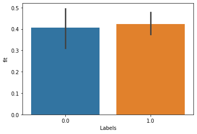

```python
sns.barplot(df_hier['Labels'],df_hier['fit'])
plt.show()
```

- we can see that customers in cluster 1.0 gave fit feedback than cluster 0.0 .

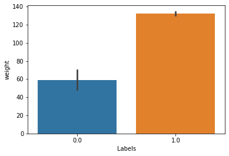

```python
sns.barplot(df_hier['Labels'],df_hier['weight'])
plt.show()
```

- we can see that weight of customers in cluster 0.0 is less than cluster 1.0.

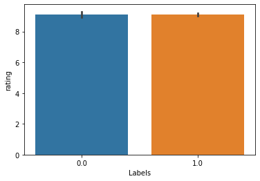

```python
sns.barplot(df_hier['Labels'],df_hier['rating'])
plt.show()
```

- we can see that the rating provided by customers is approximately the same in cluster 0.0 & 1.0.

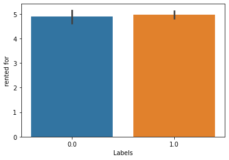

```python
sns.barplot(df_hier['Labels'],df_hier['rented for'])
plt.show()
```

- we can see that customers that rent clothes in both cluster 0.0 & 1.0 are approximately the same.

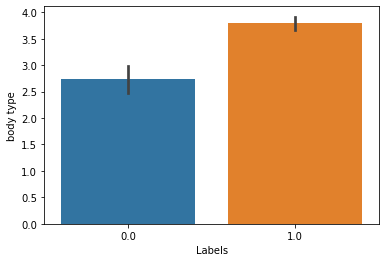

```python
sns.barplot(df_hier['Labels'],df_hier['body type'])
plt.show()
```

- we can see that the body type in cluster 1.0 is more than in cluster 0.0 .

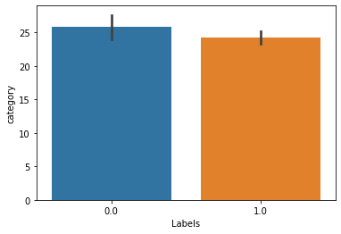

```python
sns.barplot(df_hier['Labels'],df_hier['category'])
plt.show()
```

- we can see that there are more categories in cluster than in cluster 1.0.

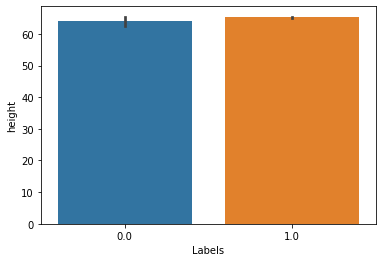

```python
sns.barplot(df_hier['Labels'],df_hier['height'])
plt.show()
```

- we can see that the heights of the customers in both cluster is approximately the same.

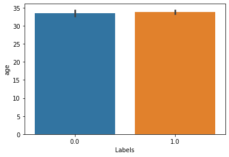

```python
sns.barplot(df_hier['Labels'],df_hier['age'])
plt.show()
```

- we can see that age of customers in cluster 1.0 is slightly more than cluster 0.0 .

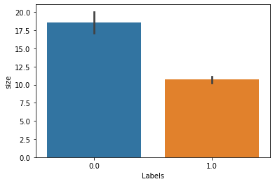

```python
sns.barplot(df_hier['Labels'],df_hier['size'])
plt.show()
```

- we can see that the products in cluster 0.0 is large in size when compared with cluster 0.0 .